# Hypothesis Testing

## Hypothesis Testing

1. State hypotheses
2. Calculate test statistic
3. p-value
4. Decision
5. Conclusion

## Hypothesis Testing for \(p\)

- A pharmaceutical company wants to show that fewer than 20% of patients who use a particular medication experience side effects
- In a clinical trial with 400 patients, they find 68 experienced side effects

## Hypothesis Testing for \(p\)

- Hypotheses

\[H_0: p \ge 0.20\] \[H_1: p < 0.20\]

From our sample, out of 400 patients, 68 experienced side effects.

\[\hat{p} = \frac{68}{400} = 0.17\]

## Hypothesis Testing for \(p\)

- Distribution of \(\hat{p}\) ASSUMING \(H_0\) is true \[\hat{p} \sim N\Big(0.20, \sqrt{\frac{0.2(1-0.2)}{400}}\Big)\]

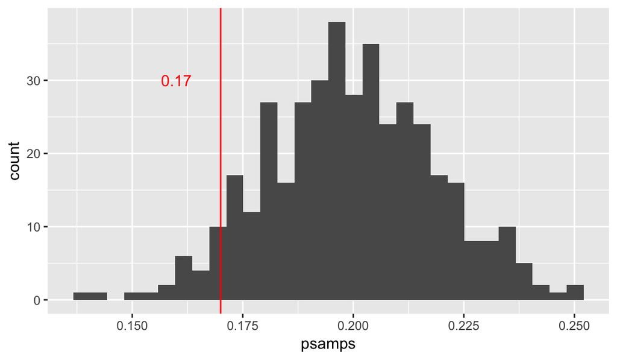

## Hypothesis Testing for \(p\)

- Test statistic

\[Z^* = \frac{\hat{p} - p_0}{\sqrt{\frac{p_0(1-p_0)}{n}}} = \frac{0.17 - 0.20}{\sqrt{\frac{0.2(1-0.2)}{400}}} = -1.5\]

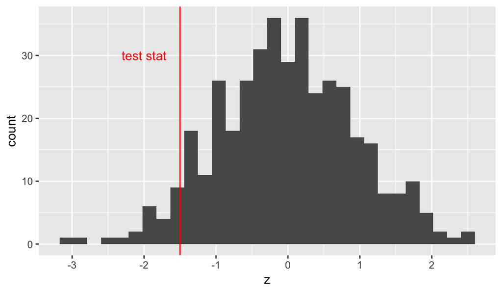

## Hypothesis Testing for \(p\)

- p-value

\[H_0: p \ge 0.20\] \[H_1: p < 0.20\]

\[P(Z < -1.5) = normalcdf(-e99,-1.5,~0,~1) = 0.0668\]

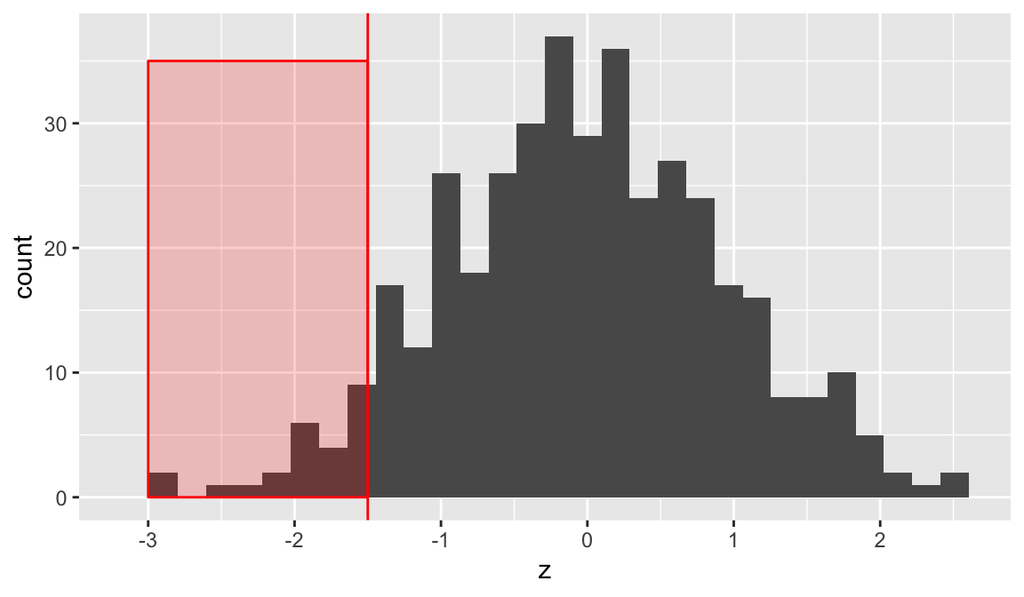

## Hypothesis Testing for \(p\)

- Decision:

- Conclusion

There is not signicant evidence to show that fewer than 20% of patients who use a particular medication experience side effects

## Hypothesis Testing for \(\mu\)

In 2008, the online travel agency Travelocity reported that summer travelers booked their airline reservations an average of 73.3 days in advance. A random sample of 40 summer travelers in 2010 was selected. The average number of days travelers booked their airline reservations in advance was 78 with a standard deviation of 6.85 days. Using α = 0.1, test the hypothesis that the average number of days reservations are booked in advance has changed since 2008.

## Hypothesis Testing for \(\mu\)

- Hypotheses

\[H_0: \mu = 73.3\] \[H_1: \mu \ne 73.3\]

From our sample of 40 summer travelers, we get a mean of 78 and s.d. of 6.85.

## Hypothesis Testing for \(\mu\)

- Distribution of \(\bar{X}\) ASSUMING \(H_0\) is true

\[\bar{X} \sim N\Big(73.3, \frac{6.85}{\sqrt{40}}\Big)\]

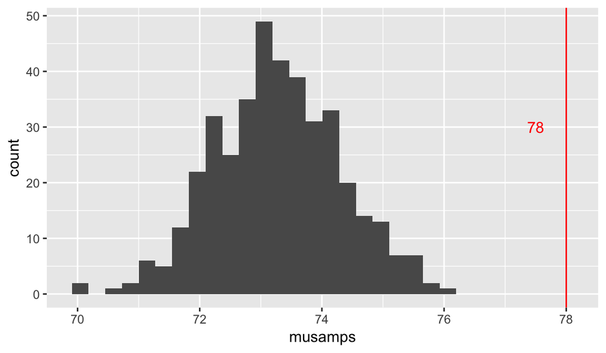

## Hypothesis Testing for \(\mu\)

- Test Statistic

\[t^* = \frac{\bar{X} - \mu_0}{s/\sqrt{n}} = \frac{78 - 73.3}{6.85/\sqrt{40}} = 4.339\]

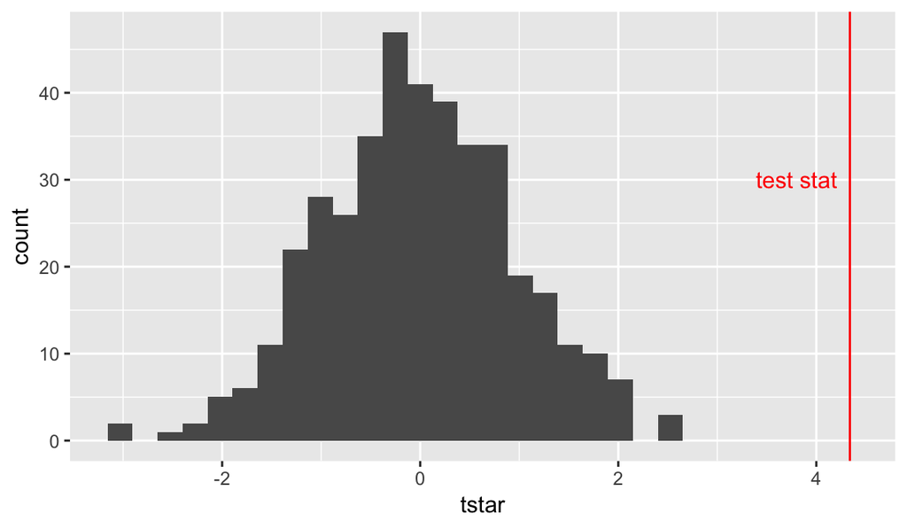

## Hypothesis Testing for \(\mu\)

- p-value

\[H_0: \mu = 73.3\] \[H_1: \mu \ne 73.3\]

\[2 \cdot P(t>4.339) = 2 \cdot tcdf(4.339,~e99,~40-1) = 0.000098\]

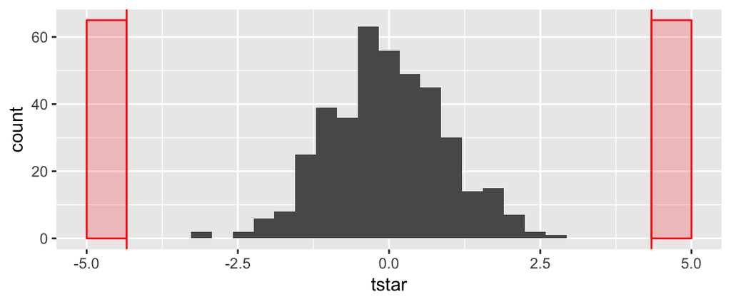

## Hypothesis Testing for \(\mu\)

- Decision:

**Reject** \(H_0\) since

\[p-value < \alpha\] \[0.000098 < 0.1\]

- Conclusion

There is signicant evidence to show that the average number of days reservations are booked in advance has changed since 2008.